# M3: Exercise

Luana Lima

## Setting R code chunk options

First R code chunk is used for setting the options for all R code chunks. The choice echo=TRUE means both code and output will appear on report, include = FALSE neither code nor output is printed.

## Loading packages and initializing

Second R code chunk is for loading packages. By setting message = FALSE, the code will appear but not the output.

```r
library(lubridate)
library(ggplot2)
library(forecast)
library(Kendall)
library(tseries)
```

## Importing data

Let’s continue working with our inflow data for reservoirs in Brazil.

```r
#Importing time series data from text file#
raw_inflow_data <- read.table(file="../Data/inflowtimeseries.txt",header=FALSE,skip=0)

#Trim the table to include only columns you need
nhydro <- ncol(raw_inflow_data)-2
nobs <- nrow(raw_inflow_data)

#If your file does not have header like this one you can add column names after
#creating the data frame
colnames(raw_inflow_data)=c("Month","Year", "HP1", "HP2","HP3","HP4", "HP5",
                            "HP6","HP7", "HP8","HP9","HP10", "HP11","HP12",
                            "HP13", "HP14","HP15")

#Checking data
head(raw_inflow_data)
```

|  | Month | Year | HP1 | HP2 | HP3 | HP4 | HP5 | HP6 | HP7 | HP8 | HP9 | HP10 | HP11 | HP12 | HP13 | HP14 | HP15 |
| --- | --- | --- | --- | --- | --- | --- | --- | --- | --- | --- | --- | --- | --- | --- | --- | --- | --- |
| 1 | Jan | 1931 | 4782 | 4076 | 2518 | 2450 | 2649 | 1462 | 450 | 968 | 246 | 2636 | 452 | 4870 | 452 | 17342 | 31270 |
| 2 | Feb | 1931 | 7323 | 7681 | 4188 | 150 | 2401 | 758 | 554 | 219 | 74 | 4158 | 457 | 4550 | 796 | 21530 | 43827 |
| 3 | Mar | 1931 | 8266 | 5921 | 3253 | 2389 | 3261 | 707 | 615 | 333 | 123 | 3847 | 631 | 6537 | 804 | 33299 | 49884 |
| 4 | Apr | 1931 | 6247 | 4600 | 2449 | 1253 | 2006 | 469 | 474 | 297 | 113 | 3291 | 510 | 7298 | 644 | 34674 | 43962 |
| 5 | May | 1931 | 3642 | 2789 | 1651 | 2374 | 2454 | 3167 | 378 | 3295 | 938 | 1956 | 276 | 4942 | 421 | 15184 | 35156 |
| 6 | Jun | 1931 | 2425 | 2062 | 1270 | 2672 | 2433 | 3236 | 301 | 2547 | 951 | 1371 | 201 | 2478 | 305 | 8611 | 25764 |

```r
str(raw_inflow_data)
```

```
## 'data.frame':    972 obs. of  17 variables:
##  $ Month: chr  "Jan" "Feb" "Mar" "Apr" ...
##  $ Year : int  1931 1931 1931 1931 1931 1931 1931 1931 1931 1931 ...
##  $ HP1  : int  4782 7323 8266 6247 3642 2425 2158 1854 1839 1896 ...
##  $ HP2  : int  4076 7681 5921 4600 2789 2062 1644 1301 1439 1340 ...
##  $ HP3  : int  2518 4188 3253 2449 1651 1270 1204 1152 1297 1259 ...
##  $ HP4  : int  2450 150 2389 1253 2374 2672 1238 605 1016 674 ...
##  $ HP5  : int  2649 2401 3261 2006 2454 2433 1798 1160 1584 1563 ...
##  $ HP6  : int  1462 758 707 469 3167 3236 1957 844 1937 1484 ...
##  $ HP7  : int  450 554 615 474 378 301 256 244 222 355 ...
##  $ HP8  : int  968 219 333 297 3295 2547 2585 1173 3596 1140 ...
##  $ HP9  : int  246 74 123 113 938 951 883 404 378 211 ...
##  $ HP10 : int  2636 4158 3847 3291 1956 1371 1186 1049 1162 1507 ...
##  $ HP11 : int  452 457 631 510 276 201 213 196 161 208 ...
##  $ HP12 : int  4870 4550 6537 7298 4942 2478 1905 1647 1453 1358 ...
##  $ HP13 : int  452 796 804 644 421 305 261 246 250 328 ...
##  $ HP14 : int  17342 21530 33299 34674 15184 8611 5939 4259 3282 3305 ...
##  $ HP15 : int  31270 43827 49884 43962 35156 25764 18109 13320 8225 8900 ...
```

## Creating the date object

Here we use the function my() from package lubridate.

```r
#using package lubridate
my_date <- paste(raw_inflow_data[,1],raw_inflow_data[,2],sep="-")
my_date <- my(my_date)  #function my from package lubridate
head(my_date)
```

```
## [1] "1931-01-01" "1931-02-01" "1931-03-01" "1931-04-01" "1931-05-01"
## [6] "1931-06-01"
```

```r
#add that to inflow_data and store in a new data frame
inflow_data <- cbind(my_date,raw_inflow_data[,3:(3+nhydro-1)])
head(inflow_data)
```

|  | my_date | HP1 | HP2 | HP3 | HP4 | HP5 | HP6 | HP7 | HP8 | HP9 | HP10 | HP11 | HP12 | HP13 | HP14 | HP15 |
| --- | --- | --- | --- | --- | --- | --- | --- | --- | --- | --- | --- | --- | --- | --- | --- | --- |
| 1 | 1931-01-01 | 4782 | 4076 | 2518 | 2450 | 2649 | 1462 | 450 | 968 | 246 | 2636 | 452 | 4870 | 452 | 17342 | 31270 |
| 2 | 1931-02-01 | 7323 | 7681 | 4188 | 150 | 2401 | 758 | 554 | 219 | 74 | 4158 | 457 | 4550 | 796 | 21530 | 43827 |
| 3 | 1931-03-01 | 8266 | 5921 | 3253 | 2389 | 3261 | 707 | 615 | 333 | 123 | 3847 | 631 | 6537 | 804 | 33299 | 49884 |
| 4 | 1931-04-01 | 6247 | 4600 | 2449 | 1253 | 2006 | 469 | 474 | 297 | 113 | 3291 | 510 | 7298 | 644 | 34674 | 43962 |
| 5 | 1931-05-01 | 3642 | 2789 | 1651 | 2374 | 2454 | 3167 | 378 | 3295 | 938 | 1956 | 276 | 4942 | 421 | 15184 | 35156 |
| 6 | 1931-06-01 | 2425 | 2062 | 1270 | 2672 | 2433 | 3236 | 301 | 2547 | 951 | 1371 | 201 | 2478 | 305 | 8611 | 25764 |

## Initial Plots

Initial time series plot.

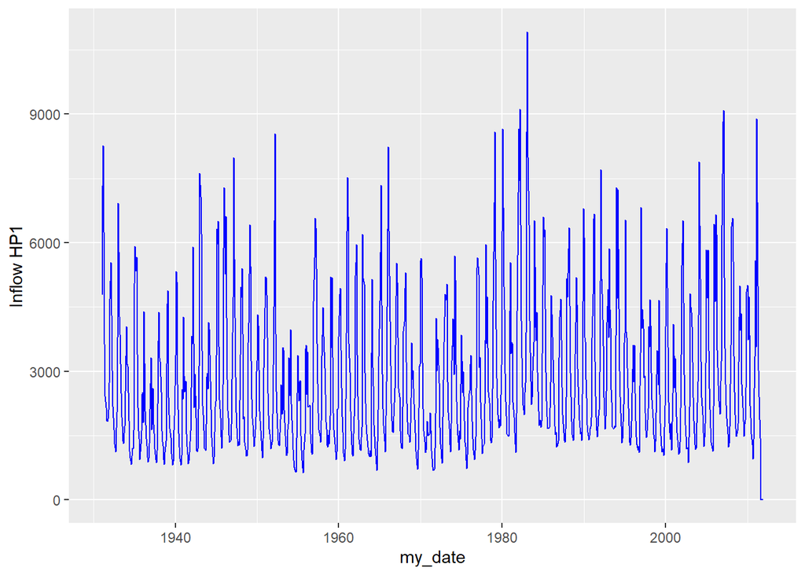

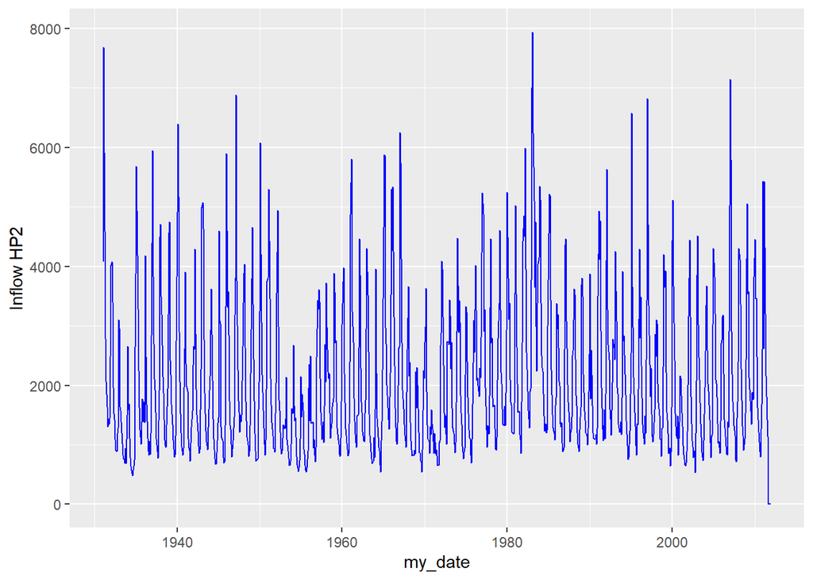

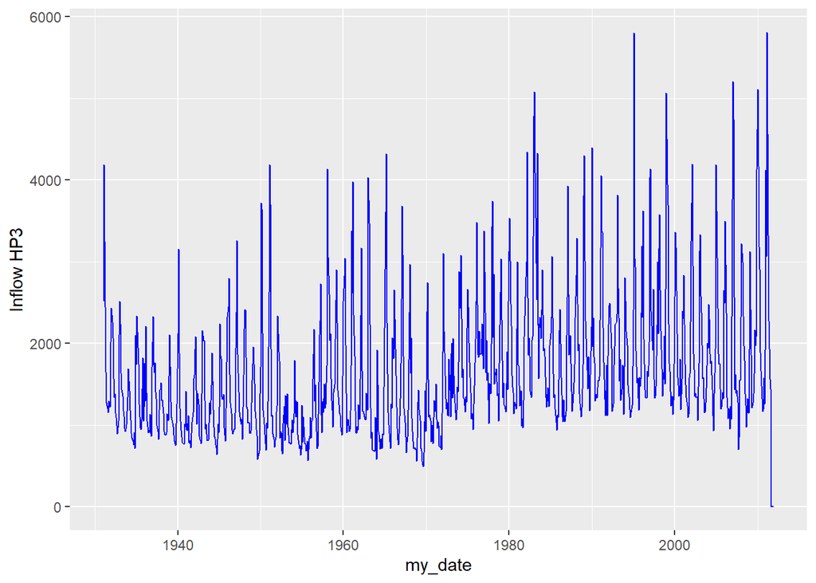

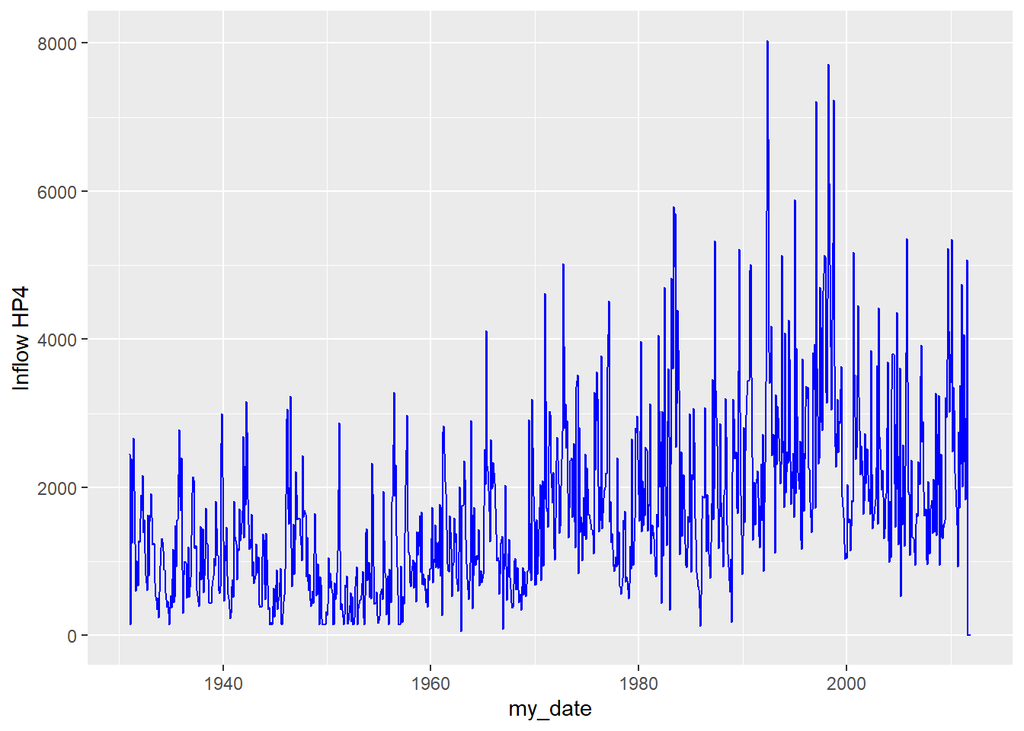

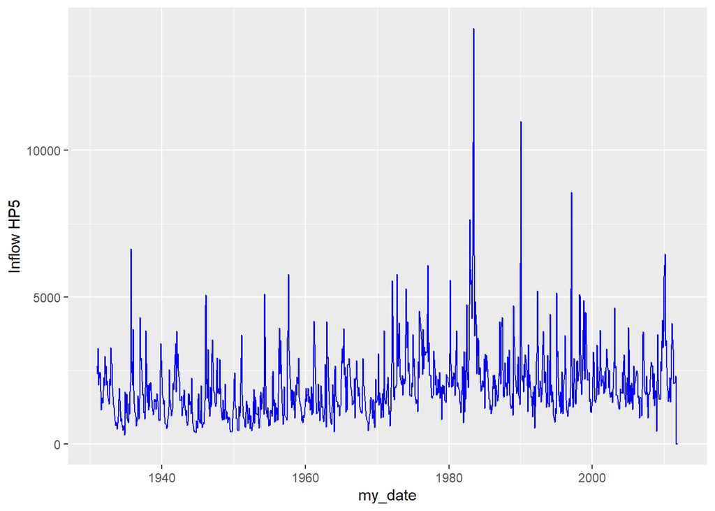

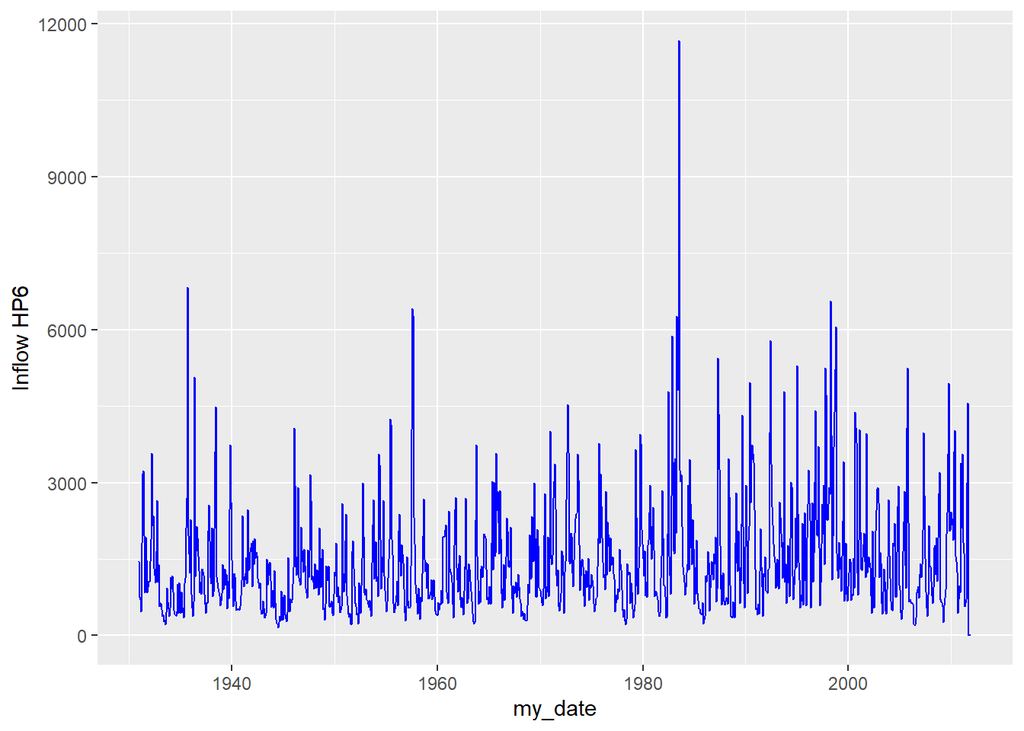

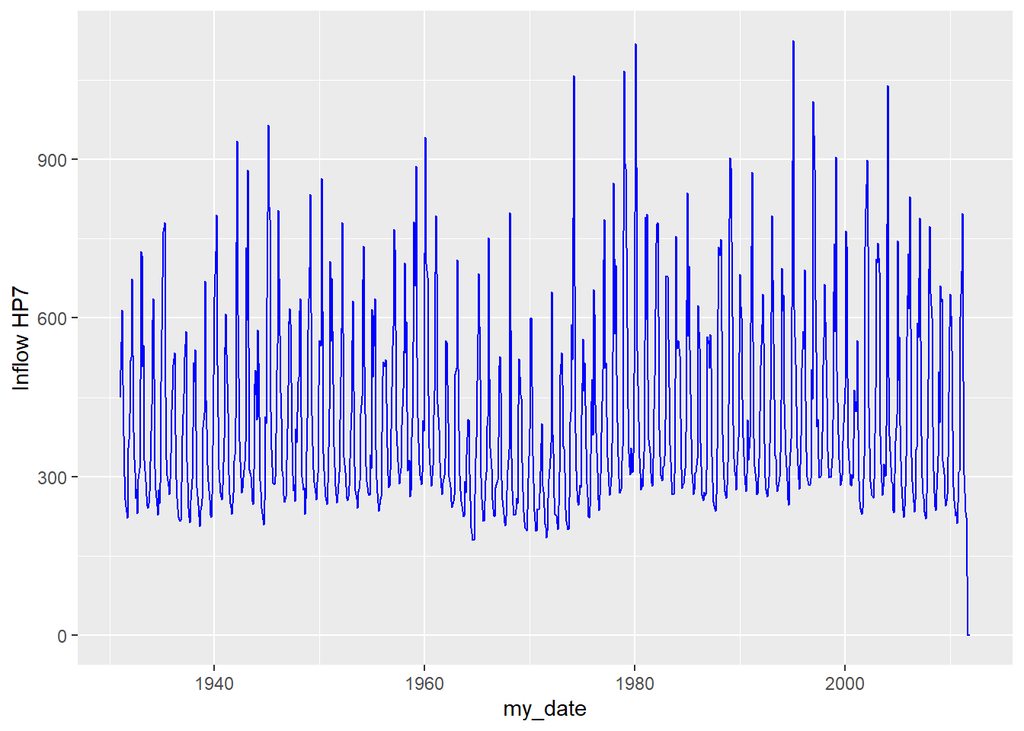

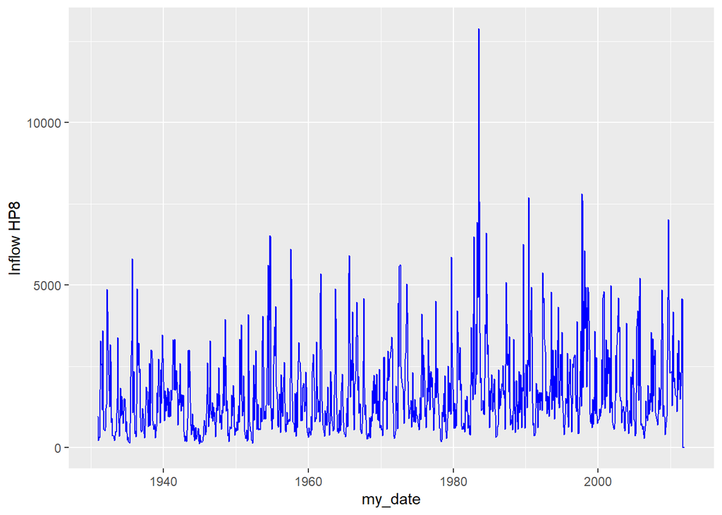

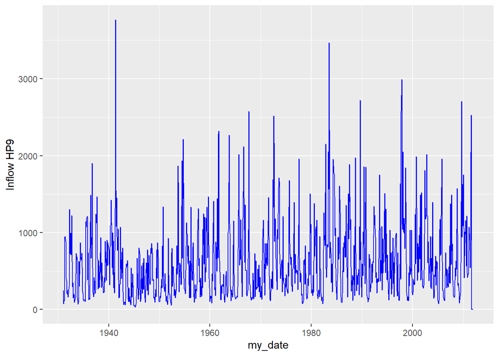

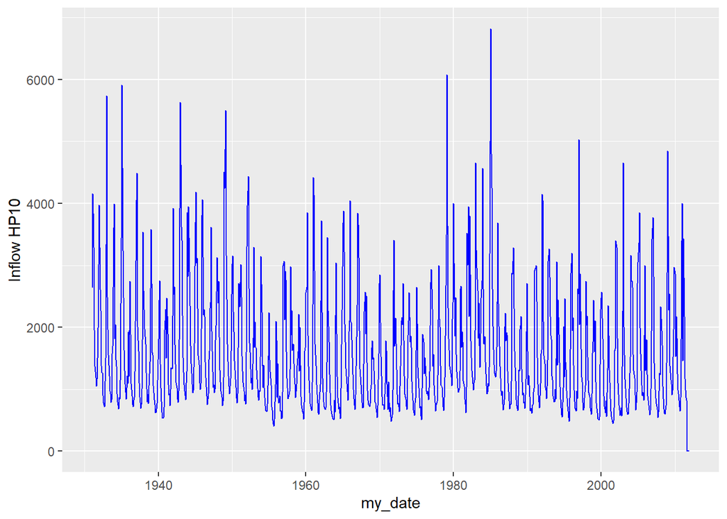

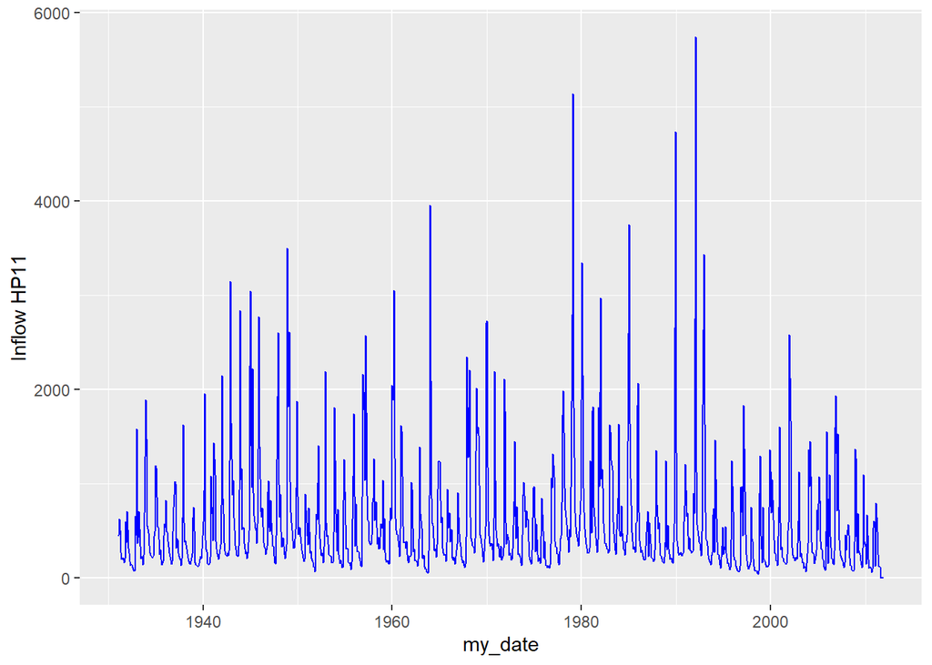

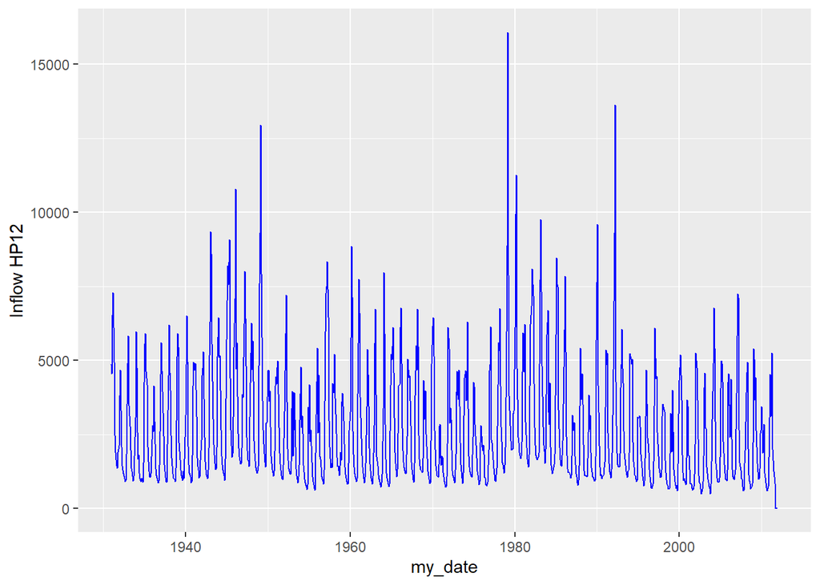

[3 more figures not shown]

```r
#using package ggplot2
for(i in 1:nhydro){
  print(ggplot(inflow_data, aes(x=my_date, y=inflow_data[,(1+i)])) +
            geom_line(color="blue") +
            ylab(paste0("Inflow ",colnames(inflow_data)[(1+i)],sep=""))
        )
}
```

## Zeros in the end on data

The initial plots showed that we have zeros in the end of the data set. It could be missing observation or observation that haven’t been observed yet. Use the tail() to find out how many zeros you have and how many lines you will need to remove.

```r
#check the final obs on data
tail(inflow_data)
```

|  | my_date | HP1 | HP2 | HP3 | HP4 | HP5 | HP6 | HP7 | HP8 | HP9 | HP10 | HP11 | HP12 | HP13 | HP14 | HP15 |
| --- | --- | --- | --- | --- | --- | --- | --- | --- | --- | --- | --- | --- | --- | --- | --- | --- |
| 967 | 2011-07-01 | 1883 | 1426 | 1560 | 2930 | 2105 | 2988 | 233 | 4578 | 2045 | 864 | 119 | 1068 | 275 | 3910 | 14162 |
| 968 | 2011-08-01 | 1444 | 1139 | 1441 | 5069 | 2328 | 4559 | 224 | 4573 | 2527 | 827 | 120 | 854 | 251 | 2561 | 8896 |
| 969 | 2011-09-01 | 0 | 0 | 0 | 0 | 0 | 0 | 0 | 0 | 0 | 0 | 0 | 0 | 0 | 0 | 0 |
| 970 | 2011-10-01 | 0 | 0 | 0 | 0 | 0 | 0 | 0 | 0 | 0 | 0 | 0 | 0 | 0 | 0 | 0 |
| 971 | 2011-11-01 | 0 | 0 | 0 | 0 | 0 | 0 | 0 | 0 | 0 | 0 | 0 | 0 | 0 | 0 | 0 |
| 972 | 2011-12-01 | 0 | 0 | 0 | 0 | 0 | 0 | 0 | 0 | 0 | 0 | 0 | 0 | 0 | 0 | 0 |

```r
#Remove last for rows by replacing current data frame
inflow_data <- inflow_data[1:(nobs-12),]

#update object with number of observations
nobs <- nobs-12

#Tail again to check if the rows were correctly removed
tail(inflow_data)
```

|  | my_date | HP1 | HP2 | HP3 | HP4 | HP5 | HP6 | HP7 | HP8 | HP9 | HP10 | HP11 | HP12 | HP13 | HP14 | HP15 |
| --- | --- | --- | --- | --- | --- | --- | --- | --- | --- | --- | --- | --- | --- | --- | --- | --- |
| 955 | 2010-07-01 | 1539 | 1214 | 1481 | 1978 | 1828 | 1449 | 227 | 2146 | 1161 | 932 | 124 | 867 | 255 | 2746 | 14043 |
| 956 | 2010-08-01 | 1289 | 886 | 1173 | 1490 | 1452 | 1238 | 233 | 1834 | 567 | 715 | 108 | 702 | 233 | 1931 | 8815 |
| 957 | 2010-09-01 | 953 | 798 | 1189 | 928 | 1564 | 439 | 212 | 1626 | 1219 | 645 | 58 | 610 | 216 | 1485 | 6512 |
| 958 | 2010-10-01 | 1411 | 1265 | 1580 | 2748 | 2268 | 971 | 251 | 1581 | 476 | 871 | 100 | 738 | 268 | 1900 | 7492 |
| 959 | 2010-11-01 | 2608 | 1681 | 1255 | 1721 | 1427 | 835 | 309 | 1109 | 415 | 1807 | 534 | 1726 | 336 | 3470 | 11387 |
| 960 | 2010-12-01 | 3338 | 2608 | 1921 | 3373 | 2203 | 3386 | 312 | 2908 | 453 | 3402 | 604 | 3064 | 380 | 7027 | 17839 |

Fixed!

## Transforming data into time series object

Many of the functions we will use require a time series object. You can transform your data in a time series using the function *ts()*.

```r
ts_inflow_data <- ts(inflow_data[,2:(2+nhydro-1)],frequency=12)
#note that we are only transforming columns with inflow data, not the date columns  #start=my_date[1],end=my_date[nobs],
head(ts_inflow_data,15)
```

```
##        HP1  HP2  HP3  HP4  HP5  HP6 HP7  HP8 HP9 HP10 HP11 HP12 HP13  HP14
## Jan 1 4782 4076 2518 2450 2649 1462 450  968 246 2636  452 4870  452 17342
## Feb 1 7323 7681 4188  150 2401  758 554  219  74 4158  457 4550  796 21530
## Mar 1 8266 5921 3253 2389 3261  707 615  333 123 3847  631 6537  804 33299
## Apr 1 6247 4600 2449 1253 2006  469 474  297 113 3291  510 7298  644 34674
## May 1 3642 2789 1651 2374 2454 3167 378 3295 938 1956  276 4942  421 15184
## Jun 1 2425 2062 1270 2672 2433 3236 301 2547 951 1371  201 2478  305  8611
## Jul 1 2158 1644 1204 1238 1798 1957 256 2585 883 1186  213 1905  261  5939
## Aug 1 1854 1301 1152  605 1160  844 244 1173 404 1049  196 1647  246  4259
## Sep 1 1839 1439 1297 1016 1584 1937 222 3596 378 1162  161 1453  250  3282
## Oct 1 1896 1340 1259  674 1563 1484 355 1140 211 1507  208 1358  328  3305
## Nov 1 2095 1447 1218  674 1404  835 371  563 252 1996  596 1905  319  6500
## Dec 1 2725 2479 2013 1278 2272 1073 419  512 197 3015  381 2121  335  8461
## Jan 2 4679 4021 2435 1259 1995 1044 520  609 159 3978  711 3811  467 14002
## Feb 2 5535 4082 2262 1895 2996 1454 525 1219 268 2615  316 4681  531 20596
## Mar 2 4310 3398 2065 1686 2392 1888 674 1332 304 2269  271 3329  501 21638
##        HP15
## Jan 1 31270
## Feb 1 43827
## Mar 1 49884
## Apr 1 43962
## May 1 35156
## Jun 1 25764
## Jul 1 18109
## Aug 1 13320
## Sep 1  8225
## Oct 1  8900
## Nov 1 13766
## Dec 1 20880
## Jan 2 33160
## Feb 2 39791
## Mar 2 48274
```

Note that ts_inflow_data has information on start, end and frequency.

## Plotting ACF and PACF

Let’s use functions Acf() and Pacf() from package “forecast”.

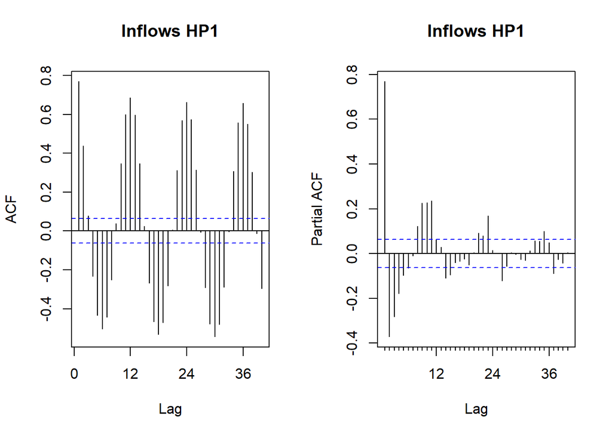

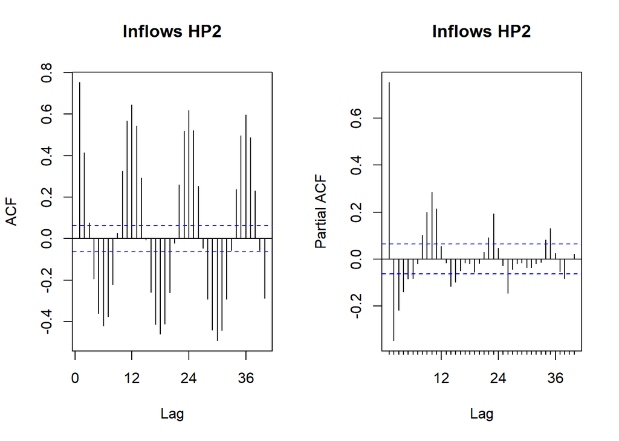

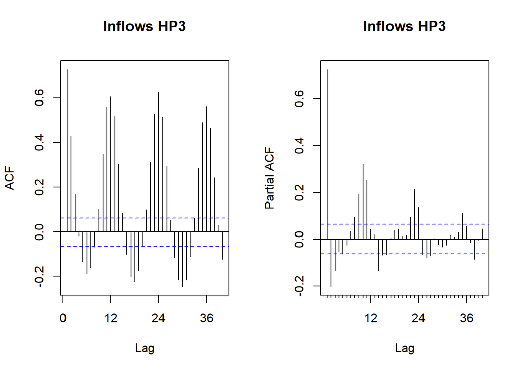

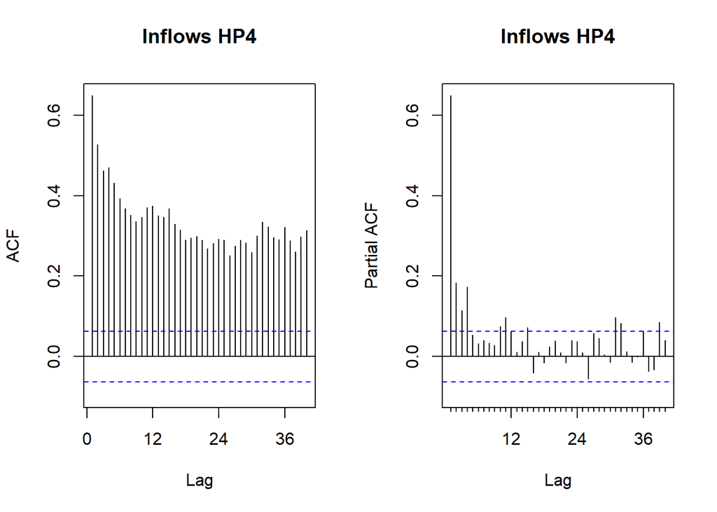

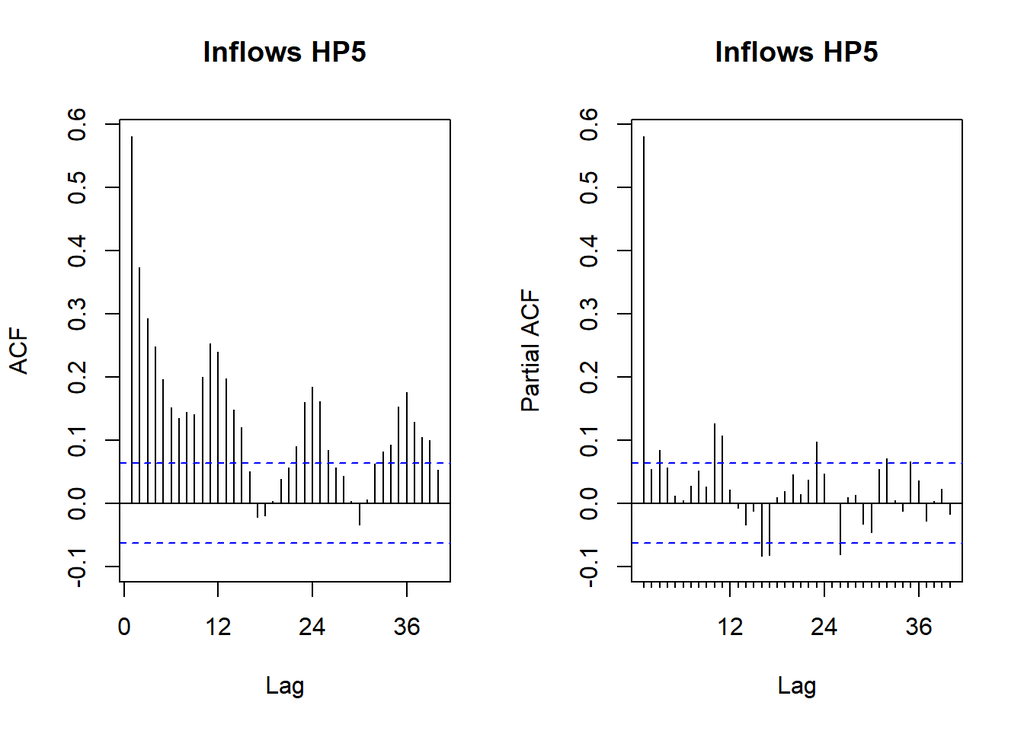

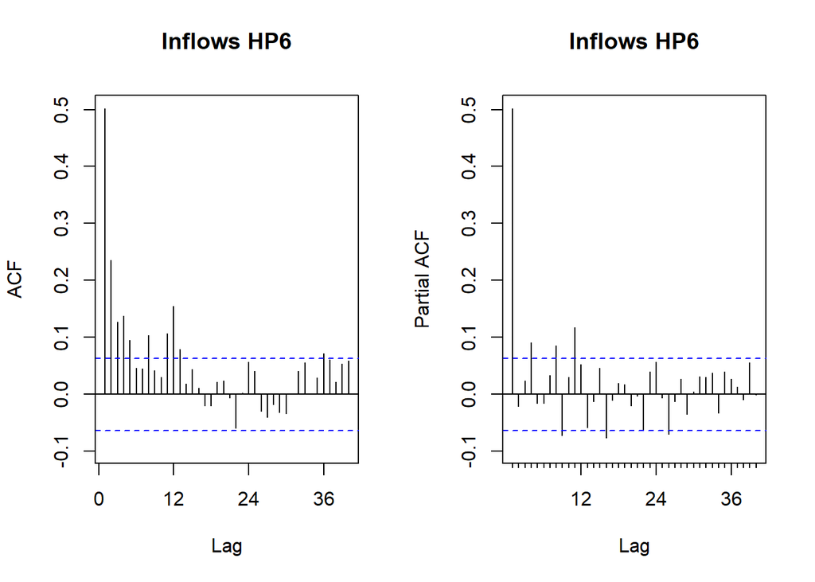

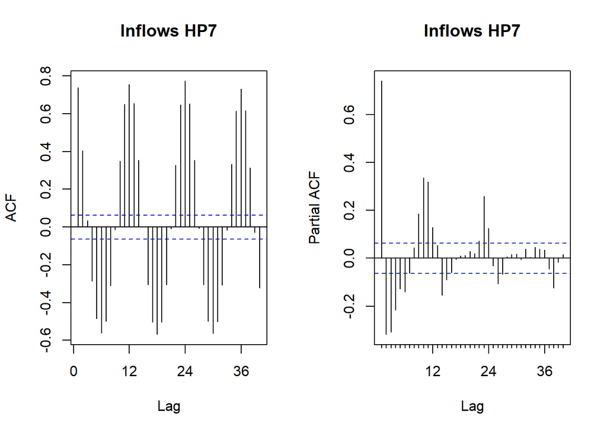

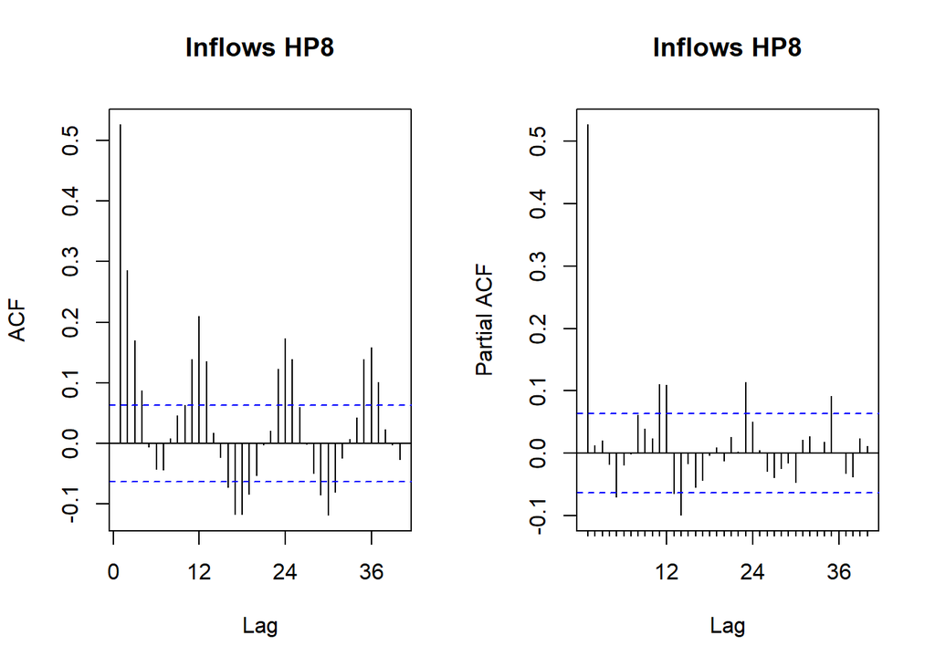

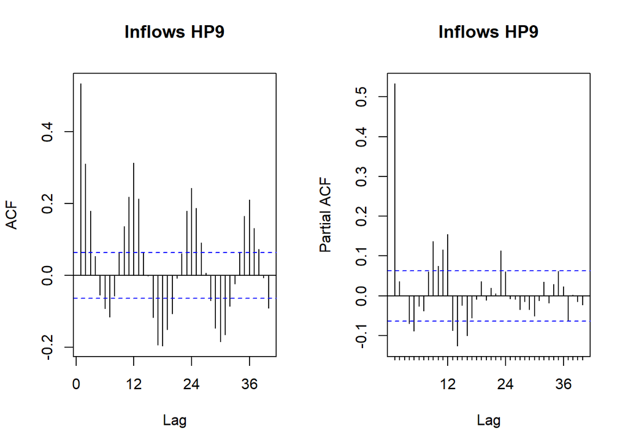

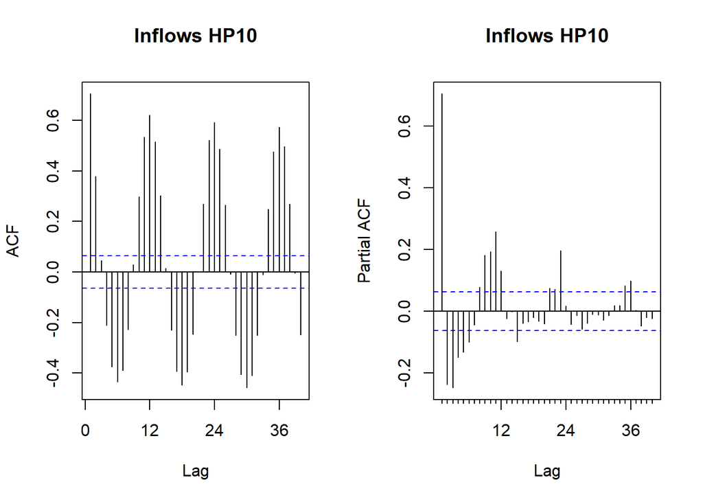

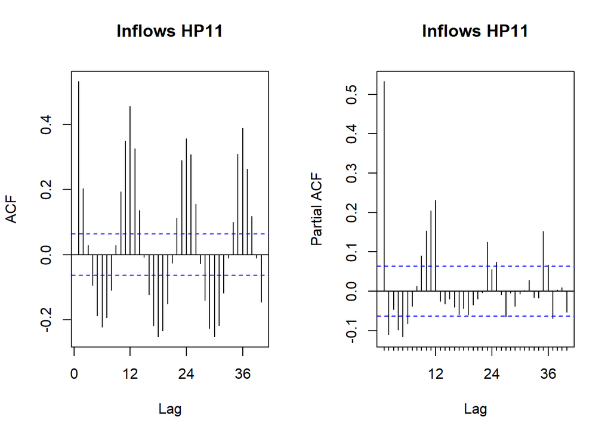

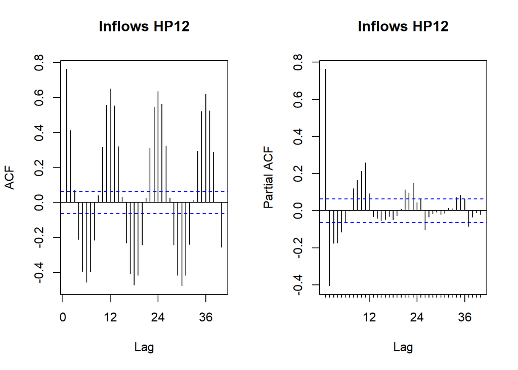

[3 more figures not shown]

```r
#Acf and Pacf for HP1
for(i in 1:nhydro){
  par(mfrow=c(1,2))  #place plot side by side
  Acf(ts_inflow_data[,i],lag.max=40,main=paste("Inflows HP",i,sep=""))
  # because I am not storing Acf() into any object, I don't need to specify plot=TRUE
  Pacf(ts_inflow_data[,i],lag.max=40,main=paste("Inflows HP",i,sep=""))
}
```

## Trend Component

Let’s identify and remove trend component like we leaned on the recorded videos for M4. You start by fitting a linear model to $Y_t=\beta_0+\beta_1*t+\epsilon_t$.

```r
#Create vector t
t <- c(1:nobs)

#Choose one hydro plant to study, as an exercise try to generalize this routine for all 15 HP
#from the plot HP4 seems to have a trend so let's play with that column
iHP=4  #change this to chekc other HP
#prep_data <- data.frame("Inflow"=inflow_data[,iHP],"Time"=t)

#Fit a linear trend to TS of iHP
linear_trend_model=lm(inflow_data[,iHP+1]~t)
summary(linear_trend_model)
```

```
##
## Call:
## lm(formula = inflow_data[, iHP + 1] ~ t)
##
## Residuals:
##     Min      1Q  Median      3Q     Max
## -2057.2  -691.1  -217.4   503.6  5786.1
##
## Coefficients:
##             Estimate Std. Error t value Pr(>|t|)
## (Intercept) 637.5519    65.4250   9.745   <2e-16 ***
## t             2.1836     0.1179  18.513   <2e-16 ***
## ---
## Signif. codes:  0 '***' 0.001 '**' 0.01 '*' 0.05 '.' 0.1 ' ' 1
##
## Residual standard error: 1013 on 958 degrees of freedom
## Multiple R-squared:  0.2635, Adjusted R-squared:  0.2627
## F-statistic: 342.7 on 1 and 958 DF,  p-value: < 2.2e-16
```

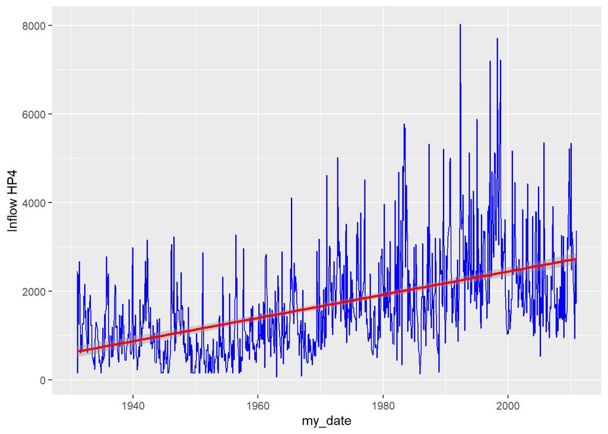

```r
beta0=as.numeric(linear_trend_model$coefficients[1])  #first coefficient is the intercept term or beta0
beta1=as.numeric(linear_trend_model$coefficients[2])  #second coefficient is the slope or beta1

#Let's plot the time series with its trend line
ggplot(inflow_data, aes(x=my_date, y=inflow_data[,(1+iHP)])) +
            geom_line(color="blue") +
            ylab(paste0("Inflow ",colnames(inflow_data)[(1+iHP)],sep="")) +
            #geom_abline(intercept = beta0, slope = beta1, color="red")
            geom_smooth(color="red",method="lm")
```

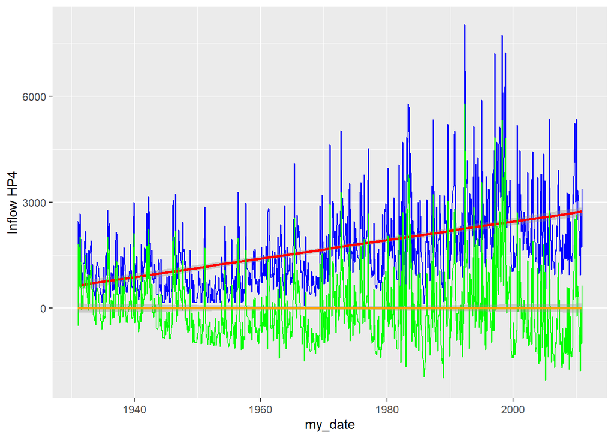

```r
#remove the trend from series
detrend_inflow_data <- inflow_data[,(iHP+1)]-(beta0+beta1*t)

#Understanding what we did
ggplot(inflow_data, aes(x=my_date, y=inflow_data[,(1+iHP)])) +
            geom_line(color="blue") +
            ylab(paste0("Inflow ",colnames(inflow_data)[(1+iHP)],sep="")) +
            #geom_abline(intercept = beta0, slope = beta1, color="red")
            geom_smooth(color="red",method="lm") +
            geom_line(aes(y=detrend_inflow_data), col="green")+
            geom_smooth(aes(y=detrend_inflow_data),color="orange",method="lm")
```

Note that blue line is our original series, red lien is our trend, green line is our original series minus the trend or in other words the detrended series. And in orange is the trend line for the detrended series which has slope 0 meaning we were able to effectively eliminate the trend with a linear model.

## Seasonal Component

Now let’s shift attention to the seasonal component.

```r
#Let's choose another HP
iHP=1

#Use seasonal means model
#First create the seasonal dummies
dummies <- seasonaldummy(ts_inflow_data[,iHP])
#this function only accepts ts object, no need to add one here because date
#object is not a column

#Then fit a linear model to the seasonal dummies
seas_means_model=lm(inflow_data[,(iHP+1)]~dummies)
summary(seas_means_model)
```

```
##
## Call:
## lm(formula = inflow_data[, (iHP + 1)] ~ dummies)
##
## Residuals:
##     Min      1Q  Median      3Q     Max
## -3414.4  -451.6   -45.7   336.6  5962.6
##
## Coefficients:
##             Estimate Std. Error t value Pr(>|t|)
## (Intercept)   3482.7      114.5  30.418  < 2e-16 ***
## dummiesJan    1202.3      161.9   7.425 2.51e-13 ***
## dummiesFeb    1469.7      161.9   9.076  < 2e-16 ***
## dummiesMar    1377.8      161.9   8.509  < 2e-16 ***
## dummiesApr     241.8      161.9   1.493    0.136
## dummiesMay    -999.5      161.9  -6.172 9.96e-10 ***
## dummiesJun   -1529.7      161.9  -9.447  < 2e-16 ***
## dummiesJul   -1887.2      161.9 -11.655  < 2e-16 ***
## dummiesAug   -2155.7      161.9 -13.313  < 2e-16 ***
## dummiesSep   -2245.4      161.9 -13.867  < 2e-16 ***
## dummiesOct   -2018.1      161.9 -12.464  < 2e-16 ***
## dummiesNov   -1335.4      161.9  -8.247 5.39e-16 ***
## ---
## Signif. codes:  0 '***' 0.001 '**' 0.01 '*' 0.05 '.' 0.1 ' ' 1
##
## Residual standard error: 1024 on 948 degrees of freedom
## Multiple R-squared:  0.6476, Adjusted R-squared:  0.6435
## F-statistic: 158.3 on 11 and 948 DF,  p-value: < 2.2e-16
```

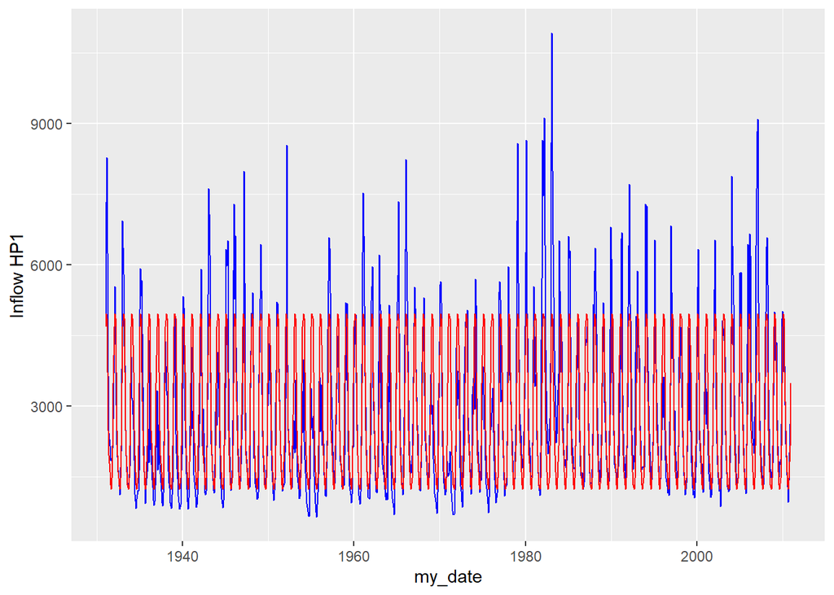

```r
#Look at the regression coefficient. These will be the values of Beta

#Store regression coefficients
beta_int=seas_means_model$coefficients[1]
beta_coeff=seas_means_model$coefficients[2:12]

#compute seasonal component
inflow_seas_comp=array(0,nobs)
for(i in 1:nobs){
  inflow_seas_comp[i]=(beta_int+beta_coeff%*%dummies[i,])
}

#Understanding what we did
ggplot(inflow_data, aes(x=my_date, y=inflow_data[,(1+iHP)])) +
            geom_line(color="blue") +
            ylab(paste0("Inflow ",colnames(inflow_data)[(1+iHP)],sep="")) +
            geom_line(aes(y=inflow_seas_comp), col="red")
```

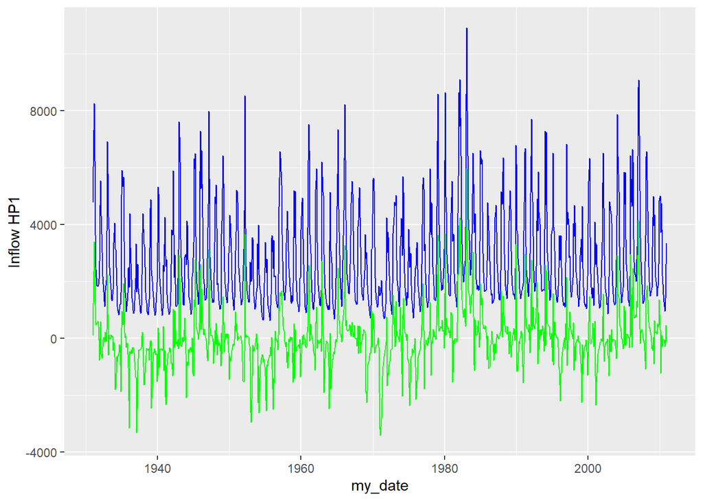

```r
#Removing seasonal component
deseason_inflow_data <- inflow_data[,(1+iHP)]-inflow_seas_comp

#Understanding what we did
ggplot(inflow_data, aes(x=my_date, y=inflow_data[,(1+iHP)])) +
            geom_line(color="blue") +
            ylab(paste0("Inflow ",colnames(inflow_data)[(1+iHP)],sep="")) +
            geom_line(aes(y=deseason_inflow_data), col="green")
```

## Stationarity Tests in R

Before we get started with the tests recall that for the year 2011 we only have data until Aug 2011. Let’s filter our dataset to remove that last year.

```r
ts_inflow_data <- as.ts(ts_inflow_data[1:960,])
my_date <- my_date[1:960]

#create new df
inflow_data_new <- cbind(my_date, ts_inflow_data)

#note that there are more elegant ways to do that using filter function from package dplyr
#Let me know if you would like to learn how to use them
```

Some test only work for non-seasonal data. SO let’s create another series with yearly averages for inflow.

```r
iHP=1
#Group data in yearly steps instances
inflow_data_matrix <- matrix(ts_inflow_data[,iHP],byrow=FALSE,nrow=12)
inflow_data_yearly <- colMeans(inflow_data_matrix)

library(dplyr)  #move this to package chunk later
```

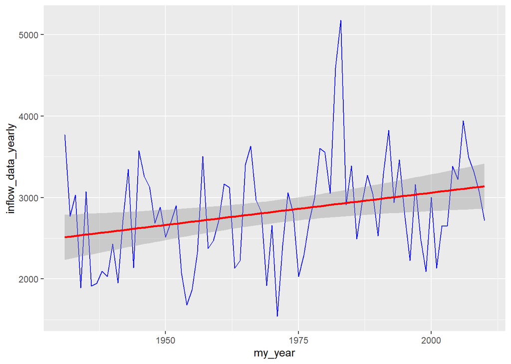

```r
my_year <- c(year(first(my_date)):year(last(my_date)))

inflow_data_new_yearly <- data.frame(my_year, inflow_data_yearly)

ggplot(inflow_data_new_yearly, aes(x=my_year, y=inflow_data_yearly)) +
            geom_line(color="blue") +
            geom_smooth(color="red",method="lm")
```

### Mann Kendall

Check for deterministic trend.

```r
#Since I have seasonal data I cannot use the simple MannKendall()
#another example of functions that need a ts object
SMKtest <- SeasonalMannKendall(ts_inflow_data[,iHP])
print("Results for Seasonal Mann Kendall /n")
```

```
## [1] "Results for Seasonal Mann Kendall /n"
```

```r
print(summary(SMKtest))
```

```
## Score =  37242 , Var(Score) = 98457224
## denominator =  460269
## tau = 0.0809, 2-sided pvalue =0.00017455
## NULL
```

```r
#Use yearly date to run Mann Kendall
print("Results of Mann Kendall on average yearly series")
```

```
## [1] "Results of Mann Kendall on average yearly series"
```

```r
print(summary(MannKendall(inflow_data_yearly)))
```

```
## Score =  618 , Var(Score) = 57933.33
## denominator =  3160
## tau = 0.196, 2-sided pvalue =0.010364
## NULL
```

### Spearman Correlation test

Also check for deterministic trend, for non-seasonal data only.

```r
#Deterministic trend with Spearman Correlation Test
print("Results from Spearman Correlation")
```

```
## [1] "Results from Spearman Correlation"
```

```r
sp_rho=cor(inflow_data_yearly,my_year,method="spearman")
print(sp_rho)
```

```
## [1] 0.2847398
```

```r
#with cor.test you can get test statistics
sp_rho=cor.test(inflow_data_yearly,my_year,method="spearman")
print(sp_rho)
```

```
##
##  Spearman's rank correlation rho
##
## data:  inflow_data_yearly and my_year
## S = 61026, p-value = 0.01069
## alternative hypothesis: true rho is not equal to 0
## sample estimates:
##       rho
## 0.2847398
```

### Augmented Dickey Fuller (ADF)

Used to detect stochastic trend.

```r
#Null hypothesis is that data has a unit root
print("Results for ADF test/n")
```

```
## [1] "Results for ADF test/n"
```

```r
print(adf.test(ts_inflow_data[,iHP],alternative = "stationary"))
```

```
##
##  Augmented Dickey-Fuller Test
##
## data:  ts_inflow_data[, iHP]
## Dickey-Fuller = -7.07, Lag order = 9, p-value = 0.01
## alternative hypothesis: stationary
```

```r
#Now let's try the yearly data
print("Results for ADF test on yearly data/n")
```

```
## [1] "Results for ADF test on yearly data/n"
```

```r
print(adf.test(inflow_data_yearly, alternative = "stationary"))
```

```
##
##  Augmented Dickey-Fuller Test
##
## data:  inflow_data_yearly
## Dickey-Fuller = -3.5308, Lag order = 4, p-value = 0.04481
## alternative hypothesis: stationary
```

##Exercise

Run the stationarity tests for the other variables HP2, HP3, …